# TV stories on gun accidents

Pavel Oleinikov

October 13, 2017

The code below demonstrates the use of GDELT API for tracking stories involving guns and children. GDELT is a project closely aligned with Google, and seems to provide the same capabilities in terms of media search as Google News.

The full documentation on the API can be found at this page: https://blog.gdeltproject.org/gdelt-doc-2-0-api-debuts/

GDELT does not store content of stories: it indexes the content, but provides only a URL to an article.

The API can return data in browser-friendly HTML, in CSV, and in JSON formats. For example, the URL below, if clicked, will open a table of article links, coming from domains in the United States, spanning the last three days, with the search terms related to children and guns:

https://api.gdeltproject.org/api/v2/doc/doc?query=(teen OR teenager OR child OR toddler OR boy OR girl OR “-year-old”) (accidentally OR unintentionally) (shot OR killed OR wounded OR fired) (weapon OR gun OR shotgun OR rifle OR pistol) sourceCountry:US&mode=artlist&TIMESPAN=3d&maxrecords=250&format=HTML

The search seems to capture various sources, including opinion pieces. From a different project, we have a list of all local TV stations in the US. For this demonstration, we filter the stories (using the script) only to those that appeared in TV news.

GDELT can go back up to 3 months, but the total number of links returned in an article link cannot exceed 250. For this reason, in the script below we iterate over 3-day periods, going back 21 days.

### Query formulation

Compared to the Google alert maintained by Everytown, the query below has a new term: “-year-old”. Other terms are very similar to what is used in the alert. It is not clear if the terms, separated by spaces, are considered as connected by AND terms or not.

##### Query argument:

> query=(teen OR teenager OR child OR toddler OR boy OR girl OR “-year-old”) (accidentally OR unintentionally) (shot OR killed OR wounded OR fired) (weapon OR gun OR shotgun OR rifle OR pistol) sourceCountry:US

If we find that we absolutely must have all of the possible combinations tested, we could generate specific strings. As of right now, GDELT does not impose any restrictions on the number of API requests and we can programmatically search for variations of search strings to narrow down our results.

> 15-year-old recovering at UTMC after being shot in neck with AR-15 Oct. 12, 2017: A 15-year-old who was shot in the neck in what police say was an accidental shooting is in stable condition. WBIR 6:41 PM. EDT October 12, 2017 CONNECT TWEET LINKEDIN GOOGLE+ PINTEREST SEVIERVILLE - UPDATE Thursday, Oct. 12, 2017The Sevierville Police Department has released the names of the people involved in what appears to be an accidental shooting.The Sevierville Police Department said Dakota Bradburn, 15, is recovering at UT Medical Center.According to an incident report, Charles James Christopher, 18, said he was messing around with his AR-15 and thought it was safe and accidentally pulled the trigger.When first responders arrived on scene, Bradburn was found laying on the floor with a gunshot wound to his neck, close to his throat. It appeared that the bullet went through his neck, came out the back of his neck, and went back into his shoulder, according to the incident report.Christopher had been applying pressure to the wound until authorities arrived, the report states.The shooting happened on Wednesday at around 3:07 p.m.No charges have been filed, according to Sevierville Police.ORIGINAL STORY Wednesday, Oct. 11, 2017A 15-year-old was shot in the neck Wednesday afternoon, according to the Sevierville Police Department.Investigators said it appears the teen was accidentally shot with an AR-15 style rifle by an 18-year-old male at a home on Nichols Street around 3 p.m. Two other men were also in the home at the time.According to the police department, the 15-year-old was alert when he was airlifted to UT Medical Center. Police are expected to release the victim’s name as well as the names of the adults once family members have been notified. © 2017 WBIR.COM CONNECT TWEET LINKEDIN GOOGLE+ PINTEREST

### Operation of the script

The script retrieves the URLs of all stories, and keeps only those that were posted on domains belonging to TV stations. Then it downloads the static HTML from the story links. (Some content may be generated and displayed only after the HTML is processed by a Web browser: such content cannot be captured via simple download of HTML text.)

The next step involves extraction of inner text from HTML. For this purpose, the script uses a library that parses XML content and extracts all `div` nodes of HTML document. Many HTML elements are not related to the story, but contain text nevertheless. (One example would be text descriptions for graphic elements, which must be present for a website to be in compliance with Americans with Disabilities Act.) At the end of this operation, there are usually over 100 text chunks.

In order to clean up the text content, the script removes the text chunks that contain JavaScript code. The script tests if a chunk contains curly braces `{ }` or a pair of parentheses with nothing in them `()`: such elements often occur in JavaScript.

After that, the script calculates text similarity between the terms from the story title and each text chunk. The chunk that has the highest score is returned as the “best paragraph”. The idea behind this approach is that certain words, important to the story, would be repeated several times. The paragraph that has the highest total frequency of these terms is the most likely candidate for story summarization.

### A sample run

We have a table with names of stations. In the script, it is referred to as `short_stations`

We will specify that we want to obtain the records from the last 3 days - argument `TIMESPAN=3d` in the URL below.

```r
library(httr)
library(XML)
library(tm)
library(plyr)

### this is the URL
url1 = 'https://api.gdeltproject.org/api/v2/doc/doc?query=(teen OR teenager OR child OR toddler OR boy OR girl OR "-year-old") (accidentally OR unintentionally) (shot OR killed OR wounded OR fired) (weapon OR gun OR shotgun OR rifle OR pistol) sourceCountry:US&mode=artlist&maxrecords=250&format=CSV&TIMESPAN=3d'

url = URLencode(url1)
s = GET(url)

df = read.csv(text = httr::content(s, as="text"), stringsAsFactors = F, header=T)
colnames(df) = c("URL", "MobileURL", "Date", "Title")
```

Right now we have a table with all hits:

```r
nrow(df)
```

```
## [1] 175
```

```r
head(df)
```

```
##                                                                                                               URL
## 1              http://www.kmbc.com/article/relative-of-slain-toddler-arrested-in-killing-of-teen-suspect/12835719
## 2                       http://www.the-messenger.com/news/local/article_ba6506ff-939e-5ab1-b3d3-919b16f55bd9.html
## 3             http://www.washingtontimes.com/news/2017/oct/12/sheriff-child-accidentally-shot-woman-in-car-after/
## 4                   http://www.fox19.com/story/36585827/sheriff-child-accidentally-shot-woman-in-car-after-church
## 5            https://www.seattletimes.com/nation-world/sheriff-child-accidentally-shot-woman-in-car-after-church/
## 6 http://www.wbko.com/content/news/Pulaski-County-grandmother-accidentally-shot-killed-by-grandson-450689663.html
##                                                                                             MobileURL
## 1  http://amp.kmbc.com/article/relative-of-slain-toddler-arrested-in-killing-of-teen-suspect/12835719
## 2
## 3 http://amp.washingtontimes.com/news/2017/oct/12/sheriff-child-accidentally-shot-woman-in-car-after/
## 4
## 5
## 6
##                  Date
## 1 2017-10-12 12:45:00
## 2 2017-10-12 22:45:00
## 3 2017-10-12 22:45:00
## 4 2017-10-12 23:45:00
## 5 2017-10-12 22:30:00
## 6 2017-10-13 04:30:00
##                                                                      Title
## 1            Relative of slain toddler arrested in killing of teen suspect
## 2 Sheriff : Child accidentally shot woman in car after church | Local News
## 3              Sheriff : Child accidentally shot woman in car after church
## 4              Sheriff : Child accidentally shot woman in car after church
## 5              Sheriff : Child accidentally shot woman in car after church
## 6        Pulaski County grandmother accidentally shot , killed by grandson
```

We then extract the domain name and retain only those stories that were posted by TV stations. We also add information on the station - its city and full name.

```r
k = grepl("(?<=http://www.).*?(?=.com)", df$URL, perl=T, ignore.case=T)
m = regexpr("(?<=http://www.).*?(?=.com)", df$URL[k], perl=T, ignore.case=T)
t = regmatches(df$URL[k], m)

df2 = df[k, ]
df2$domain = toupper(t)

r = df2$domain %in% short_stations$UniqueIdentifier
df2 = df2[r, ]

tv_story = merge(x = df2,
                 y = short_stations[ , c("UniqueIdentifier", "StationName", "Location")],
                 by.x="domain", by.y="UniqueIdentifier")
```

The number of stories has shrunk:

```r
nrow(tv_story)
```

```
## [1] 26
```

```r
head(tv_story)
```

```
##   domain
## 1   KCRA
## 2   KLTV
## 3   KMBC
## 4   KSDK
## 5   KSWO
## 6   KTEN
##                                                                                                                   URL
## 1                    http://www.kcra.com/article/grandfather-accidentally-shot-killed-by-4-year-old-grandson/12822060
## 2 http://www.kltv.com/story/36569157/good-samaritan-trying-to-help-victim-of-dog-attack-accidentally-shoots-kills-her
## 3                  http://www.kmbc.com/article/relative-of-slain-toddler-arrested-in-killing-of-teen-suspect/12835719
## 4                   http://www.ksdk.com/news/crime/relative-of-slain-toddler-arrested-in-killing-of-suspect/482663140
## 5                       http://www.kswo.com/story/36561080/sheriff-oklahoma-zookeepers-husband-accidentally-shot-self
## 6                       http://www.kten.com/story/36562082/sheriff-oklahoma-zookeepers-husband-accidentally-shot-self
##                                                                                               MobileURL
```

[output cut: 27 more lines]

An interesting feature is that many stations repost stories from other regions. Thus, the same story will appear several times. Because computationally it is not very taxing, we are not clustering the stories as of right now.

Now we follow up the links and download HTML from the websites. We extract text chunks, remove those that look like JavaScript, extract the individual terms from the story’s title, and perform the count. The code below does it for the first story (we set `j=1` in the code).

```r
## display information for the first story
tv_story[1, ]
```

```
##   domain
## 1   KCRA
##                                                                                                URL
## 1 http://www.kcra.com/article/grandfather-accidentally-shot-killed-by-4-year-old-grandson/12822060
##                                                                                          MobileURL
## 1 http://amp.kcra.com/article/grandfather-accidentally-shot-killed-by-4-year-old-grandson/12822060
##                  Date
## 1 2017-10-11 10:45:00
##                                                               Title
## 1 Grandfather accidentally shot to death by 4 - year - old grandson
##      StationName       Location
## 1 KCRA-SAC (NBC) Sacramento, CA
```

```r
tv_story$place = ""
tv_story$best_para = ""

j = 1
s = GET(tv_story$URL[j])
x = htmlParse(file=s, asText=T)

s = xpathApply(x, path="//div", fun=xmlValue)
s = gsub("\t", "", s)
s = gsub("\n", " ", s)
s = gsub("[ ]{2,}", " ", s)

s2 = gsub("[ ]?-[ ]?", "-", tv_story$Title[j])
t = strsplit(s2, split=" ")[[1]]
```

```r
## the number of text chunks we have
length(s)
```

```
## [1] 122
```

```r
## the terms from the title
t
```

```
## [1] "Grandfather"  "accidentally" "shot"         "to"
## [5] "death"        "by"           "4-year-old"   "grandson"
```

```r
### remove chunks that look like JavaScript
k = grepl("[{}\\]", s) | grepl("()", s, fixed=T)
s = s[!k]

## the number of chunks retained
length(s)
```

```
## [1] 87
```

Now we construct a document-term matrix and count the occurrences of title terms. For illustrative purposes, we make a plot, showing the total sum of term frequencies per text chunk:

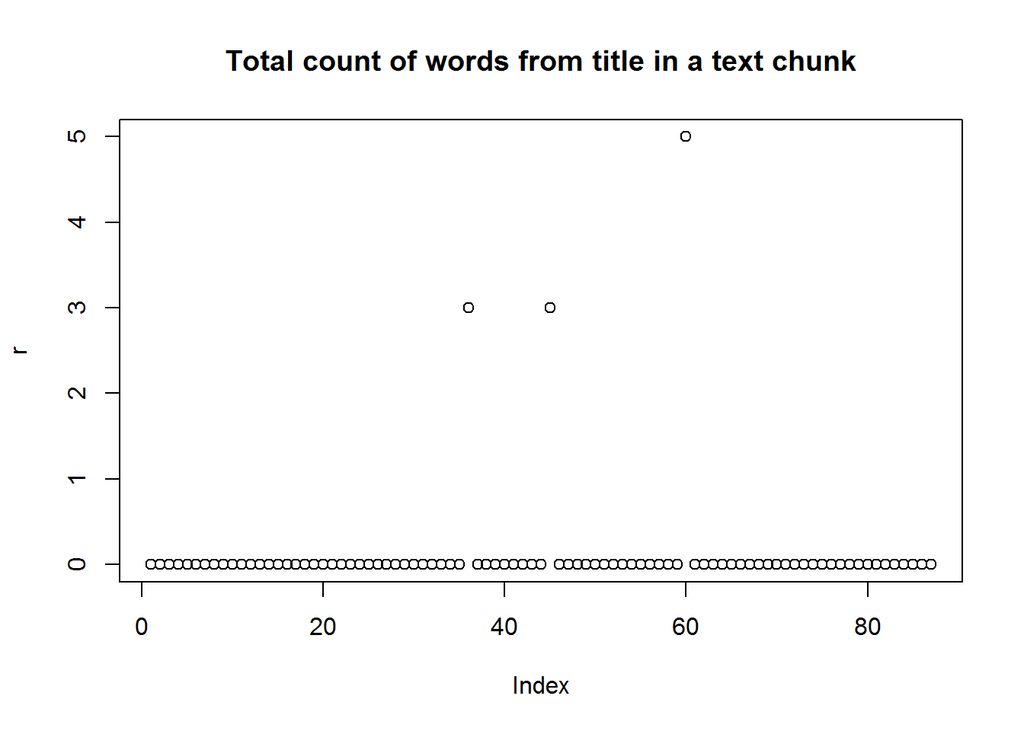

```r
v = Corpus(VectorSource(s))

dtm = DocumentTermMatrix(x=v, control=list(dictionary=t))
m = as.matrix(dtm)
r = rowSums(x=m)
plot(r, main="Total count of words from title in a text chunk")
```

```r
tv_story$best_para[j] = s[which.max(r)]
```

We then take the chunk with the highest count and save it as our best summary of the story.

```r
s[which.max(r)]
```

```
## [1] " Perquimans County, NC  A North Carolina man died Sunday after his 4-year-old grandson accidentally shot him. Advertisement According to WAVY, the boy and his grandfather, identified as Danny Patrick, 57, were reportedly shooting a rifle Sunday in a rural part of Perquimans County. At some p…
```

And in the end we can test to see if the chunk has a string that looks like a geographic reference:

```r
s2 = regexpr("^[A-Za-z ]{2,}, [A-Za-z.]{2,6}(?=[^A-Za-z.])", tv_story$best_para[j], perl=T)
if (s2 > 0) {
  tv_story$place[j] = regmatches(tv_story$best_para[j], s2)[1]
  cat(tv_story$place[j])
  }
```

```
##  Perquimans County, NC
```

The script below packages these operations into a loop which iterates over a period of time, setting the intervals at three days. We are doing this to avoid losing data due to the restriction on the maximal number of records returned (which is 250, regardless of the time interval).

The result is saved into a CSV file.

```r
library(httr)
library(XML)
library(tm)

url1 = 'https://api.gdeltproject.org/api/v2/doc/doc?query=(teen OR teenager OR child OR toddler OR boy OR girl OR "-year-old") (accidentally OR unintentionally) (shot OR killed OR wounded OR fired) (weapon OR gun OR shotgun OR rifle OR pistol) sourceCountry:US&mode=artlist&maxrecords=250&format=CSV'

today = Sys.time()
earliest_date = today - 72*60*60
latest_date = today

res = data.frame()

while (earliest_date > (today - 21*24*60*60)) {
  cat("The STARTDATETIME is", strftime(earliest_date, "%Y-%m-%d %H:%M:%S"), "\n")
  url2 = paste(url1,
               "&ENDDATETIME=", strftime(latest_date, "%Y%m%d%H%M%S"),
               "&STARTDATETIME=", strftime(earliest_date, "%Y%m%d%H%M%S"),
               sep="")

  url = URLencode(url2)
  s = GET(url)

  df = read.csv(text = httr::content(s, as="text"), stringsAsFactors = F, header=T)
  colnames(df) = c("URL", "MobileURL", "Date", "Title")

  k = grepl("(?<=http://www.).*?(?=.com)", df$URL, perl=T, ignore.case=T)
  m = regexpr("(?<=http://www.).*?(?=.com)", df$URL[k], perl=T, ignore.case=T)
  t = regmatches(df$URL[k], m)

  df2 = df[k, ]
  df2$domain = toupper(t)

  r = df2$domain %in% short_stations$UniqueIdentifier
  df2 = df2[r, ]

  tv_story = merge(x = df2,
                   y = short_stations[ , c("UniqueIdentifier", "StationName", "Location")],
                   by.x="domain", by.y="UniqueIdentifier")

  tv_story$place = ""
  tv_story$best_para = ""

  for (j in 1:nrow(tv_story)) {
    s = GET(tv_story$URL[j])
    x = htmlParse(file=s, asText=T)

    s = xpathApply(x, path="//div", fun=xmlValue)
    s = gsub("\t", "", s)
    s = gsub("\n", " ", s)
    s = gsub("[ ]{2,}", " ", s)

    s2 = gsub("[ ]?-[ ]?", "-", tv_story$Title[j])
    t = strsplit(s2, split=" ")[[1]]

    k = grepl("[{}\\]", s) | grepl("()", s, fixed=T)
    s = s[!k]

    v = Corpus(VectorSource(s))

    dtm = DocumentTermMatrix(x=v, control=list(dictionary=t))
    m = as.matrix(dtm)
    r = rowSums(x=m)
    tv_story$best_para[j] = s[which.max(r)]

    s2 = regexpr("^[A-Za-z ]{2,}, [A-Za-z.]{2,6}(?=[^A-Za-z.])", tv_story$best_para[j], perl=T)
    if (s2 > 0) {
      tv_story$place[j] = regmatches(tv_story$best_para[j], s2)[1]
    }

  }

  res = rbind.fill(res, tv_story)

  earliest_date = earliest_date - 72*60*60
  latest_date = latest_date - 72*60*60

}
```

```
## The STARTDATETIME is 2017-10-10 12:03:18
## The STARTDATETIME is 2017-10-07 12:03:18
## The STARTDATETIME is 2017-10-04 12:03:18
## The STARTDATETIME is 2017-10-01 12:03:18
## The STARTDATETIME is 2017-09-28 12:03:18
```

```
## No encoding supplied: defaulting to UTF-8.
## No encoding supplied: defaulting to UTF-8.
```

```
## The STARTDATETIME is 2017-09-25 12:03:18
```

```
## No encoding supplied: defaulting to UTF-8.
## No encoding supplied: defaulting to UTF-8.
## No encoding supplied: defaulting to UTF-8.
## No encoding supplied: defaulting to UTF-8.
## No encoding supplied: defaulting to UTF-8.
```

```r
write.csv(res, "tv_results.csv", row.names=F)
```